# **Opracowanie rekomendacji dotyczących pracowników na podstawie analizy danych dla działu HR**

## Wstęp do projektu

Niniejszy projekt stanowi doskonałą okazję do analizy zestawu danych i budowy modeli predykcyjnych, które mogą dostarczyć cennych wniosków dla działu Zasobów Ludzkich (HR) w dużej firmie konsultingowej. Celem projektu jest przewidzenie, czy pracownik opuści firmę, wykorzystując do tego modele regresji lub modele uczenia maszynowego.

Rezultatem projektu będą dwa kluczowe artefakty, które mogą zostać przedstawione przyszłym pracodawcom. Pierwszym z nich będzie krótka, jednostronicowa prezentacja wyników, skierowana do zewnętrznych interesariuszy ds. danych w firmie Salifort Motors. Drugim artefaktem będzie kompletny notatnik z kodem, zawierający wszystkie etapy analizy.

Aby osiągnąć cele projektu, wybierzemy jedno z podejść – model regresji lub model uczenia maszynowego. Przykład przedstawiony w dalszej części dokumentu ilustruje oba podejścia.

# **Etapy PACE**

### Analiza kontekstu biznesowego i identyfikacja problemu

Dział Zasobów Ludzkich firmy Salifort Motors zwrócił się z prośbą o wsparcie w analizie danych dotyczących satysfakcji pracowników, zebranych w celu poprawy warunków pracy w organizacji. Ich głównym pytaniem jest zidentyfikowanie kluczowych czynników, które mogą skłaniać pracowników do opuszczenia firmy.

Celem tego projektu jest analiza danych zebranych przez Dział Zasobów Ludzkich oraz opracowanie modelu predykcyjnego, który pozwoli przewidzieć, czy dany pracownik opuści firmę. Analiza ta umożliwi identyfikację kluczowych czynników wpływających na decyzję pracowników o odejściu, a stworzony model będzie narzędziem wspierającym Dział HR w podejmowaniu decyzji dotyczących polityki zatrudnienia i działań zwiększających retencję talentów w firmie.

### Zapoznajmy się z zestawem danych HR

W ramach tego laboratorium będziemy pracować z zestawem danych zawierającym 15 000 wierszy oraz 10 kolumn, które reprezentują następujące zmienne:

**Uwaga**: Nie trzeba pobierać żadnych danych, aby ukończyć to laboratorium. Więcej informacji na temat danych znajdziesz w ich źródle. [Kaggle](https://www.kaggle.com/datasets/mfaisalqureshi/hr-analytics-and-job-prediction?select=HR_comma_sep.csv).

| Variable | Description |  |
| --- | --- | --- |
| satisfaction_level | Employee-reported job satisfaction level [0–1] |  |
| last_evaluation | Score of employee's last performance review [0–1] |  |
| number_project | Number of projects employee contributes to |  |
| average_monthly_hours | Average number of hours employee worked per month |  |
| time_spend_company | How long the employee has been with the company (years) |  |
| Work_accident | Whether or not the employee experienced an accident while at work |  |
| left | Whether or not the employee left the company |  |
| promotion_last_5years | Whether or not the employee was promoted in the last 5 years |  |
| Department | The employee's department |  |
| salary | The employee's salary (U.S. dollars) |  |

**Zaimportujmy** niezbędne pakiety oraz **załadujmy** zestaw danych.

```python
# Import packages
### YOUR CODE HERE ###

# For data manipulation
import numpy as np
import pandas as pd

# For data visualization
import matplotlib.pyplot as plt
import seaborn as sns

# For displaying all of the columns in dataframes
pd.set_option('display.max_columns', None)

# For data modeling
from xgboost import XGBClassifier
from xgboost import XGBRegressor
from xgboost import plot_importance

from sklearn.linear_model import LogisticRegression
from sklearn.tree import DecisionTreeClassifier
from sklearn.ensemble import RandomForestClassifier

# For metrics and helpful functions
from sklearn.model_selection import GridSearchCV, train_test_split
from sklearn.metrics import accuracy_score, precision_score, recall_score,\
f1_score, confusion_matrix, ConfusionMatrixDisplay, classification_report
from sklearn.metrics import roc_auc_score, roc_curve
from sklearn.tree import plot_tree

# For saving models
import pickle
```

Do załadowania zestawu danych o nazwie `HR_capstone_dataset.csv` wykorzystajmy bibliotekę `Pandas`.

```python
# RUN THIS CELL TO IMPORT YOUR DATA.

# Load dataset into a dataframe
### YOUR CODE HERE ###
df0 = pd.read_csv("HR_capstone_dataset.csv")


# Display first few rows of the dataframe
### YOUR CODE HERE ###
df0.head(10)
```

|  | satisfaction_level | last_evaluation | number_project | average_montly_hours | time_spend_company | Work_accident | left | promotion_last_5years | Department | salary |
| --- | --- | --- | --- | --- | --- | --- | --- | --- | --- | --- |
| 0 | 0.38 | 0.53 | 2 | 157 | 3 | 0 | 1 | 0 | sales | low |
| 1 | 0.80 | 0.86 | 5 | 262 | 6 | 0 | 1 | 0 | sales | medium |
| 2 | 0.11 | 0.88 | 7 | 272 | 4 | 0 | 1 | 0 | sales | medium |
| 3 | 0.72 | 0.87 | 5 | 223 | 5 | 0 | 1 | 0 | sales | low |
| 4 | 0.37 | 0.52 | 2 | 159 | 3 | 0 | 1 | 0 | sales | low |
| 5 | 0.41 | 0.50 | 2 | 153 | 3 | 0 | 1 | 0 | sales | low |
| 6 | 0.10 | 0.77 | 6 | 247 | 4 | 0 | 1 | 0 | sales | low |
| 7 | 0.92 | 0.85 | 5 | 259 | 5 | 0 | 1 | 0 | sales | low |
| 8 | 0.89 | 1.00 | 5 | 224 | 5 | 0 | 1 | 0 | sales | low |
| 9 | 0.42 | 0.53 | 2 | 142 | 3 | 0 | 1 | 0 | sales | low |

### Podstawowe informacje na temat danych

```python
# Gather basic information about the data
### YOUR CODE HERE ###
df0.info()
```

```
<class 'pandas.core.frame.DataFrame'>
RangeIndex: 14999 entries, 0 to 14998
Data columns (total 10 columns):
 #   Column                 Non-Null Count  Dtype
---  ------                 --------------  -----
 0   satisfaction_level     14999 non-null  float64
 1   last_evaluation        14999 non-null  float64
 2   number_project         14999 non-null  int64
 3   average_montly_hours   14999 non-null  int64
 4   time_spend_company     14999 non-null  int64
 5   Work_accident          14999 non-null  int64
 6   left                   14999 non-null  int64
 7   promotion_last_5years  14999 non-null  int64
 8   Department             14999 non-null  object
 9   salary                 14999 non-null  object
dtypes: float64(2), int64(6), object(2)
memory usage: 1.1+ MB
```

### Statystyki opisowe dotyczące danych

```python
# Gather descriptive statistics about the data
### YOUR CODE HERE ###
df0.describe()
```

|  | satisfaction_level | last_evaluation | number_project | average_montly_hours | time_spend_company | Work_accident | left | promotion_last_5years |
| --- | --- | --- | --- | --- | --- | --- | --- | --- |
| count | 14999.000000 | 14999.000000 | 14999.000000 | 14999.000000 | 14999.000000 | 14999.000000 | 14999.000000 | 14999.000000 |
| mean | 0.612834 | 0.716102 | 3.803054 | 201.050337 | 3.498233 | 0.144610 | 0.238083 | 0.021268 |
| std | 0.248631 | 0.171169 | 1.232592 | 49.943099 | 1.460136 | 0.351719 | 0.425924 | 0.144281 |
| min | 0.090000 | 0.360000 | 2.000000 | 96.000000 | 2.000000 | 0.000000 | 0.000000 | 0.000000 |
| 25% | 0.440000 | 0.560000 | 3.000000 | 156.000000 | 3.000000 | 0.000000 | 0.000000 | 0.000000 |
| 50% | 0.640000 | 0.720000 | 4.000000 | 200.000000 | 3.000000 | 0.000000 | 0.000000 | 0.000000 |
| 75% | 0.820000 | 0.870000 | 5.000000 | 245.000000 | 4.000000 | 0.000000 | 0.000000 | 0.000000 |
| max | 1.000000 | 1.000000 | 7.000000 | 310.000000 | 10.000000 | 1.000000 | 1.000000 | 1.000000 |

### Zmiana nazwy kolumn

```python
# Display all column names
### YOUR CODE HERE ###
df0.columns
```

```
Index(['satisfaction_level', 'last_evaluation', 'number_project',
       'average_montly_hours', 'time_spend_company', 'Work_accident', 'left',
       'promotion_last_5years', 'Department', 'salary'],
      dtype='object')
```

```python
# Rename columns as needed
### YOUR CODE HERE ###
df0 = df0.rename(columns={'Work_accident': 'work_accident',
                          'average_montly_hours': 'average_monthly_hours',
                          'time_spend_company': 'tenure',
                          'Department': 'department'})

# Display all column names after the update
### YOUR CODE HERE ###
df0.columns
```

```
Index(['satisfaction_level', 'last_evaluation', 'number_project',
       'average_monthly_hours', 'tenure', 'work_accident', 'left',
       'promotion_last_5years', 'department', 'salary'],
      dtype='object')
```

Sprawdźmy, czy w danych występują jakiekolwiek brakujące wartości.

```python
# Check for missing values
### YOUR CODE HERE ###
df0.isna().sum()
```

```
satisfaction_level       0
last_evaluation          0
number_project           0
average_monthly_hours    0
tenure                   0
work_accident            0
left                     0
promotion_last_5years    0
department               0
salary                   0
dtype: int64
```

W danych nie występują żadne brakujące wartości.

### Sprawdźmy, czy występują zduplikowane wiersze.

```python
# Check for duplicates
### YOUR CODE HERE ###
df0.duplicated().sum()
```

```
3008
```

```python
duplicate_percentage = round(df0.duplicated().sum()/len(df0)*100,3)
```

```python
# Display the result with a percentage sign
print(f"Procent zduplikowanych wierszy: {duplicate_percentage}%")
```

```
Procent zduplikowanych wierszy: 20.055%
```

`3 008` wierszy jest zduplikowanych, co stanowi 20% całego zestawu danych.

```python
# Inspect some rows containing duplicates as needed
### YOUR CODE HERE ###
df0[df0.duplicated()].head(10)
```

|  | satisfaction_level | last_evaluation | number_project | average_monthly_hours | tenure | work_accident | left | promotion_last_5years | department | salary |
| --- | --- | --- | --- | --- | --- | --- | --- | --- | --- | --- |
| 396 | 0.46 | 0.57 | 2 | 139 | 3 | 0 | 1 | 0 | sales | low |
| 866 | 0.41 | 0.46 | 2 | 128 | 3 | 0 | 1 | 0 | accounting | low |
| 1317 | 0.37 | 0.51 | 2 | 127 | 3 | 0 | 1 | 0 | sales | medium |
| 1368 | 0.41 | 0.52 | 2 | 132 | 3 | 0 | 1 | 0 | RandD | low |
| 1461 | 0.42 | 0.53 | 2 | 142 | 3 | 0 | 1 | 0 | sales | low |
| 1516 | 0.40 | 0.50 | 2 | 127 | 3 | 0 | 1 | 0 | IT | low |
| 1616 | 0.37 | 0.46 | 2 | 156 | 3 | 0 | 1 | 0 | sales | low |
| 1696 | 0.39 | 0.56 | 2 | 160 | 3 | 0 | 1 | 0 | sales | low |
| 1833 | 0.10 | 0.85 | 6 | 266 | 4 | 0 | 1 | 0 | sales | low |
| 12000 | 0.38 | 0.53 | 2 | 157 | 3 | 0 | 1 | 0 | sales | low |

```python
# Drop duplicates and save resulting dataframe in a new variable as needed
### YOUR CODE HERE ###
df1 = df0.drop_duplicates(keep='first')
# Display first few rows of new dataframe as needed
### YOUR CODE HERE ###
df1.head(10)
```

|  | satisfaction_level | last_evaluation | number_project | average_monthly_hours | tenure | work_accident | left | promotion_last_5years | department | salary |
| --- | --- | --- | --- | --- | --- | --- | --- | --- | --- | --- |
| 0 | 0.38 | 0.53 | 2 | 157 | 3 | 0 | 1 | 0 | sales | low |
| 1 | 0.80 | 0.86 | 5 | 262 | 6 | 0 | 1 | 0 | sales | medium |
| 2 | 0.11 | 0.88 | 7 | 272 | 4 | 0 | 1 | 0 | sales | medium |
| 3 | 0.72 | 0.87 | 5 | 223 | 5 | 0 | 1 | 0 | sales | low |
| 4 | 0.37 | 0.52 | 2 | 159 | 3 | 0 | 1 | 0 | sales | low |
| 5 | 0.41 | 0.50 | 2 | 153 | 3 | 0 | 1 | 0 | sales | low |
| 6 | 0.10 | 0.77 | 6 | 247 | 4 | 0 | 1 | 0 | sales | low |
| 7 | 0.92 | 0.85 | 5 | 259 | 5 | 0 | 1 | 0 | sales | low |
| 8 | 0.89 | 1.00 | 5 | 224 | 5 | 0 | 1 | 0 | sales | low |
| 9 | 0.42 | 0.53 | 2 | 142 | 3 | 0 | 1 | 0 | sales | low |

Aby zidentyfikować potencjalne wartości odstające (tzw. outliers) w zestawie danych, przeprowadzimy wizualizację za pomocą wykresu pudełkowego (boxplot).

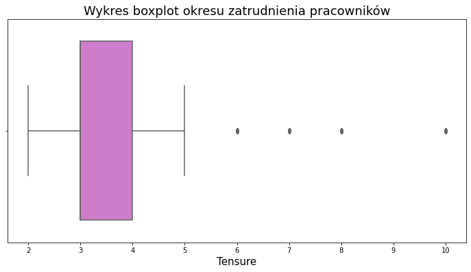

```python
# Create a boxplot to visualize distribution of `tenure` and detect any outliers
### YOUR CODE HERE ###
plt.figure(figsize=(12,6))
plt.title('Wykres boxplot okresu zatrudnienia pracowników', fontsize=18)
sns.boxplot(x=df1['tenure'],color='orchid')
plt.xlabel('Tensure',fontsize=15)
plt.show()
```

```python
# Determine the number of rows containing outliers
### YOUR CODE HERE ###

# Compute the 25th percentile value in `tenure`
percentile25 = df1['tenure'].quantile(0.25)

# Compute the 75th percentile value in `tenure`
percentile75 = df1['tenure'].quantile(0.75)

# Compute the interquartile range in `tenure`
iqr = percentile75 - percentile25

# Define the upper limit and lower limit for non-outlier values in `tenure`
upper_limit = percentile75 + 1.5 * iqr
lower_limit = percentile25 - 1.5 * iqr
print("Dolna granica:", lower_limit)
print("Górna granica:", upper_limit)

# Identify subset of data containing outliers in `tenure`
outliers = df1[(df1['tenure'] > upper_limit) | (df1['tenure'] < lower_limit)]

# Count how many rows in the data contain outliers in `tenure`
print("Liczba wierszy w danych zawierających wartości odstające w `tenure`:", len(outliers))
```

```
Dolna granica: 1.5
Górna granica: 5.5
Liczba wierszy w danych zawierających wartości odstające w `tenure`: 824
```

Niektóre modele są bardziej wrażliwe na wartości odstające niż inne. Podczas budowy modelu musimy zastanowić się nad usunięciem wartości odstających, uwzględniając specyfikę wybranego modelu.

### Eksploracja danych

Aby rozpocząć analizę, najpierw określimy liczbę pracowników, którzy opuścili firmę, a następnie obliczymy, jaki procent całkowitej liczby pracowników stanowi ta grupa.

```python
# Get numbers of people who left vs. stayed
### YOUR CODE HERE ###
print(df1['left'].value_counts())
print('-------------------------------')
# Get percentages of people who left vs. stayed
### YOUR CODE HERE ###
print(df1['left'].value_counts(normalize=True))
```

```
0    10000
1     1991
Name: left, dtype: int64
-------------------------------
0    0.833959
1    0.166041
Name: left, dtype: float64
```

### Wizualizacja danych

Teraz skupmy się na analizie wybranych zmiennych i opracujmy wykresy, które umożliwią lepsze zobrazowanie relacji między tymi zmiennymi w danych.

Rozpocznijmy od stworzenia wykresu `pudełkowego` (boxplot), który przedstawi rozkład `average_monthly_hours` w kontekście wartości `number_project`, porównując pracowników, którzy pozostali, z tymi, którzy odeszli.

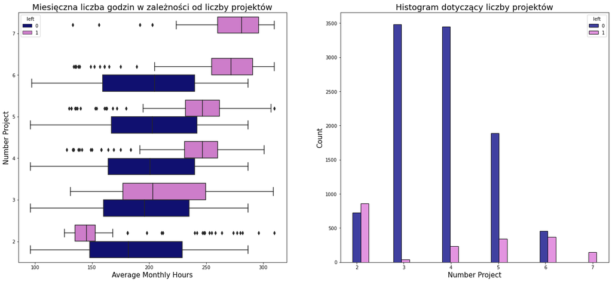

```python
# Create a plot as needed
### YOUR CODE HERE ###

# Set figure and axes
fig, ax = plt.subplots(1, 2, figsize = (23,10))

# Create boxplot showing `average_monthly_hours` distributions for `number_project`, comparing employees who stayed versus those who left
custom_palette = ['navy', 'orchid']
sns.boxplot(data=df1, x='average_monthly_hours', y='number_project', hue='left', orient="h", ax=ax[0], palette = custom_palette )
ax[0].invert_yaxis()
ax[0].set_title('Miesięczna liczba godzin w zależności od liczby projektów', fontsize='18')
ax[0].set_xlabel('Average Monthly Hours', fontsize=15)  # Add x-axis label
ax[0].set_ylabel('Number Project', fontsize=15)  # Add x-axis label


# Create histogram showing distribution of `number_project`, comparing employees who stayed versus those who left
tenure_stay = df1[df1['left']==0]['number_project']
tenure_left = df1[df1['left']==1]['number_project']
sns.histplot(data=df1, x='number_project', hue='left', multiple='dodge', shrink=2, ax=ax[1], palette = custom_palette)
ax[1].set_title('Histogram dotyczący liczby projektów', fontsize='18')
ax[1].set_xlabel('Number Project', fontsize=15)  # Add x-axis label
ax[1].set_ylabel('Count', fontsize=15)  # Add x-axis label


# Display the plots
plt.show()
```

Może być oczywiste, że pracownicy zaangażowani w większą liczbę projektów przepracowują więcej godzin. W tym przypadku widać, że średnia liczba godzin pracy w obu grupach (osoby które zostały i osoby które się zwolniły) wzrasta wraz z liczbą projektów. Niemniej jednak, z wykresu wyłaniają się pewne istotne obserwacje.

1. Wśród pracowników, którzy opuścili firmę, można wyróżnić dwie grupy: (A) tych, którzy pracowali znacznie mniej niż ich koledzy z tą samą liczbą projektów oraz (B) tych, którzy pracowali znacznie więcej. Pracownicy z grupy A mogli zostać zwolnieni, lub mogli to być ci, którzy już złożyli wypowiedzenie i otrzymali mniej godzin z powodu zbliżającego się odejścia. Z kolei pracownicy z grupy B prawdopodobnie zrezygnowali z pracy, ponieważ ich intensywna praca mogła świadczyć o dużym wkładzie w realizowane projekty, a więc mogli być kluczowymi członkami zespołów projektowych.
2. Każdy pracownik, który miał siedem projektów, opuścił firmę, a zakres międzykwartylowy godzin pracy w tej grupie oraz w grupie pracowników z sześcioma projektami wynosił około 255 – 295 godzin miesięcznie — co stanowi znacznie wyższy wynik niż w pozostałych grupach
3. Optymalna liczba projektów, nad którymi powinni pracować pracownicy, wydaje się wynosić 3 – 4. W przypadku tych grup stosunek pracowników, którzy odeszli, do tych, którzy pozostali, jest bardzo niski.
4. Zakładając tydzień pracy wynoszący 40 godzin i dwa tygodnie urlopu rocznie, średnia liczba godzin pracy miesięcznie dla pracowników pracujących od poniedziałku do piątku wynosi 50 tygodni * 40 godzin tygodniowo / 12 miesięcy = 166,67 godzin miesięcznie. Oznacza to, że oprócz pracowników zaangażowanych w dwa projekty, każda grupa — nawet ci, którzy pozostali w firmie — pracowała znacznie więcej godzin. Wydaje się, że pracownicy są tutaj przeciążeni pracą.

Kolejnym krokiem w analizie będzie weryfikacja, czy wszyscy pracownicy, którzy zrealizowali siedem projektów, faktycznie opuścili firmę.

```python
# Get value counts of stayed/left for employees with 7 projects
df1[df1['number_project']==7]['left'].value_counts()
```

```
1    145
Name: left, dtype: int64
```

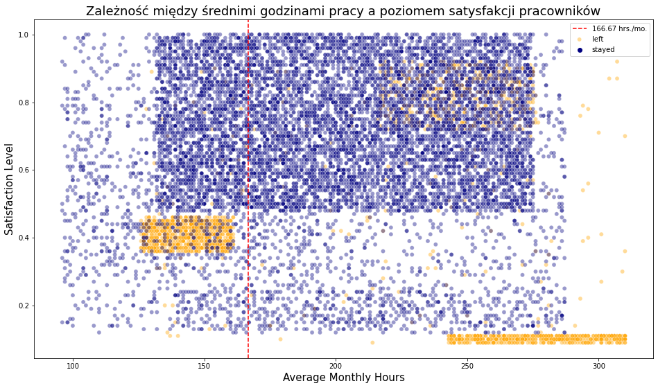

```python
# Create scatterplot of `average_monthly_hours` versus `satisfaction_level`, comparing employees who stayed versus those who left
plt.figure(figsize=(16, 9))
custom_palette = ['navy', 'orange']
sns.scatterplot(data=df1, x='average_monthly_hours', y='satisfaction_level', hue='left', alpha=0.4,palette = custom_palette  )
plt.axvline(x=166.67, color='red', label='166.67 hrs./mo.', ls='--')
plt.legend(labels=['166.67 hrs./mo.', 'left', 'stayed'])
plt.title('Zależność między średnimi godzinami pracy a poziomem satysfakcji pracowników', fontsize='18');
plt.xlabel('Average Monthly Hours', fontsize='15')
plt.ylabel('Satisfaction Level', fontsize='15')

plt.show()
```

Dodatkowo, wykres przedstawia inną grupę pracowników, którzy odeszli, ale mieli bardziej typowe godziny pracy. Mimo to ich satysfakcja wynosiła tylko około 0.4. Przyczyn odejścia tej grupy nie jest łatwo określić – możliwe, że czuli presję, aby pracować dłużej, obserwując swoich bardziej zapracowanych kolegów, co mogło wpłynęło na ich poziom satysfakcji.

Na końcu, istnieje grupa pracowników, którzy pracowali od 210 do 280 godzin miesięcznie i mieli satysfakcję w przedziale od 0.7 do 0.9.

Warto zwrócić uwagę na nietypowy kształt rozkładów, co może sugerować manipulację danymi lub stosowanie danych syntetycznych.

W następnej wizualizacji warto rozważyć przedstawienie poziomów satysfakcji w kontekście długości zatrudnienia.

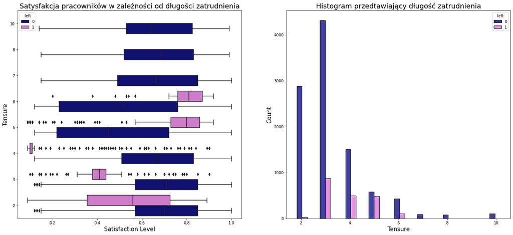

```python
# Create a plot as needed
### YOUR CODE HERE ###

# Set figure and axes
fig, ax = plt.subplots(1, 2, figsize = (23,10))

# Create boxplot showing distributions of `satisfaction_level` by tenure, comparing employees who stayed versus those who left
custom_palette = ['navy', 'orchid']
sns.boxplot(data=df1, x='satisfaction_level', y='tenure', hue='left', orient="h", ax=ax[0],palette= custom_palette)
ax[0].invert_yaxis()
ax[0].set_title('Satysfakcja pracowników w zależności od długości zatrudnienia', fontsize='18')
ax[0].set_xlabel('Satisfaction Level', fontsize=15)  # Add x-axis label
ax[0].set_ylabel('Tensure', fontsize=15)  # Add x-axis label


# Create histogram showing distribution of `tenure`, comparing employees who stayed versus those who left
tenure_stay = df1[df1['left']==0]['tenure']
tenure_left = df1[df1['left']==1]['tenure']
sns.histplot(data=df1, x='tenure', hue='left', multiple='dodge', shrink=5, ax=ax[1], palette= custom_palette)
ax[1].set_title('Histogram przedtawiający długość zatrudnienia', fontsize='18')
ax[1].set_xlabel('Tensure', fontsize=15)  # Add x-axis label
ax[1].set_ylabel('Count', fontsize=15)  # Add x-axis label

plt.show();
```

Analizując wykres, można wyróżnić kilka kluczowych obserwacji:

- Pracownicy, którzy opuścili firmę, dzielą się na dwie główne grupy: niezadowolonych z krótszym stażem oraz bardzo zadowolonych z średnim stażem.
- Pracownicy z czteroletnim stażem, którzy odeszli, wykazują wyjątkowo niski poziom satysfakcji. Warto zbadać, czy zmiany w polityce firmy mogły mieć wpływ na tę grupę w tym okresie.
- Najdłużej zatrudnieni pracownicy zostali w firmie, a ich poziom satysfakcji był zbliżony do satysfakcji nowszych pracowników, którzy również pozostali.
- Histogram pokazuje, że liczba pracowników z dłuższym stażem jest stosunkowo niewielka, co może sugerować, że są to osoby na wyższych stanowiskach z lepszym wynagrodzeniem.

Kolejnym krokiem będzie obliczenie średnich i medianowych wyników satysfakcji zarówno dla pracowników, którzy odeszli, jak i tych, którzy pozostali w firmie.

```python
df1.groupby(['left'])['satisfaction_level'].agg([np.mean,np.median])
```

| left | mean | median |
| --- | --- | --- |
| 0 | 0.667365 | 0.69 |
| 1 | 0.440271 | 0.41 |

Jak można się było spodziewać, zarówno średnia, jak i mediana wyników satysfakcji pracowników, którzy odeszli, są niższe w porównaniu do tych, którzy pozostali. Co interesujące, wśród pracowników, którzy zostali, średni poziom satysfakcji jest nieco niższy niż mediana, co może sugerować, że rozkład satysfakcji jest lewo-skośny.

Kolejnym krokiem będzie analiza wynagrodzeń w kontekście długości zatrudnienia.

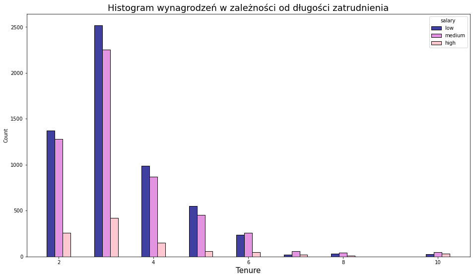

```python
# Create a plot as needed
### YOUR CODE HERE ###

# Plot tenured histogram
plt.figure(figsize=(16, 9))
plt.title('Histogram wynagrodzeń w zależności od długości zatrudnienia', fontsize=18)

# Define a custom palette with specific colors for each hue category
custom_palette = ['navy', 'orchid', 'lightpink']

sns.histplot(data=df1, x='tenure', hue='salary', discrete=True, hue_order=['low', 'medium', 'high'], palette=custom_palette, multiple='dodge', shrink=.5)

plt.xlabel('Tenure', fontsize=15)
plt.show()
```

Powyższy wykres wskazuje, że pracownicy z dłuższym stażem nie stanowili nadmiernej większości wśród lepiej opłacanych pracowników.

Kolejnym krokiem jest zbadanie, czy długie godziny pracy są skorelowane z wysokimi ocenami w ostatniej ewaluacji. Można to zrobić, tworząc wykres punktowy, który zestawia `average_monthly_hours` z `last_evaluation`.

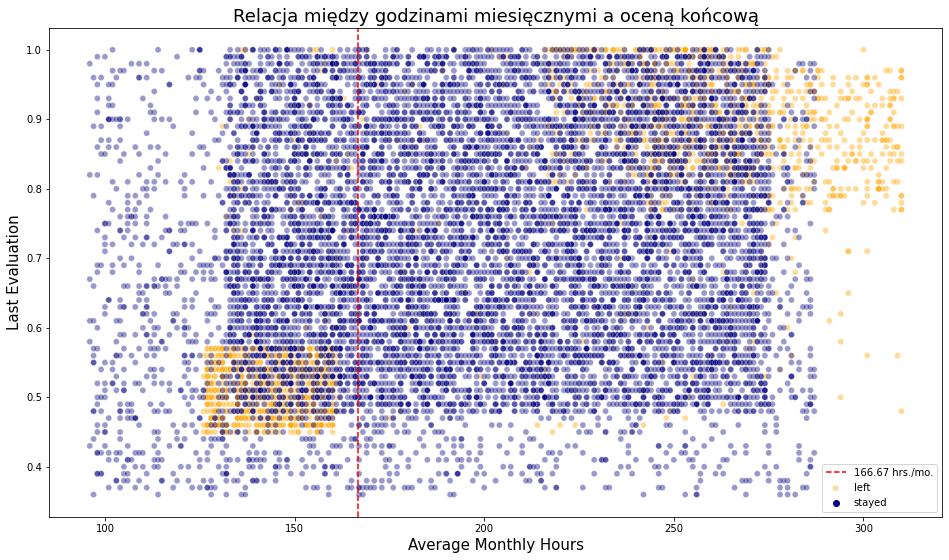

```python
# Create a plot as needed
### YOUR CODE HERE ###

# Create scatterplot of `average_monthly_hours` versus `last_evaluation`
plt.figure(figsize=(16, 9))
custom_palette = ['navy', 'orange']
sns.scatterplot(data=df1, x='average_monthly_hours', y='last_evaluation', hue='left', alpha=0.4,palette = custom_palette )
plt.axvline(x=166.67, color='red', label='166.67 hrs./mo.', ls='--')
plt.legend(labels=['166.67 hrs./mo.', 'left', 'stayed'])
plt.title('Relacja między godzinami miesięcznymi a oceną końcową', fontsize='18');
plt.xlabel('Average Monthly Hours', fontsize = '15')
plt.ylabel('Last Evaluation', fontsize = '15')

plt.show()
```

Z powyższego wykresu typu `scatterplot` można wyciągnąć kilka kluczowych wniosków:

- Wykres ukazuje dwie grupy pracowników, którzy odeszli: osoby przemęczone, które uzyskiwały bardzo dobre wyniki, oraz pracowników, którzy pracowali nieco poniżej średniej miesięcznej wynoszącej 166,67 godzin i mieli niższe oceny.
- Wygląda na to, że istnieje pewna korelacja między liczba przepracowanych godzin a oceną końcową.
- W górnym lewym kwadrancie wykresu nie ma dużego procentu pracowników; długie godziny pracy niekoniecznie przekładają się na wysokie oceny.
- Większość pracowników w tej firmie pracuje znacznie powyżej 167 godzin miesięcznie.

Następnym krokiem w analizie będzie sprawdzenie, czy pracownicy, którzy mają długi staż pracy w firmie, otrzymali awans w ciągu ostatnich pięciu lat.

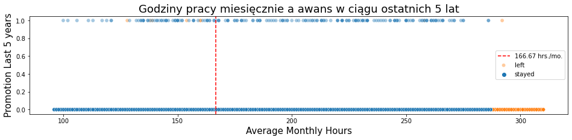

```python
# Create a plot as needed
### YOUR CODE HERE ###
# Create plot to examine relationship between `average_monthly_hours` and `promotion_last_5years`
plt.figure(figsize=(16, 3))
sns.scatterplot(data=df1, x='average_monthly_hours', y='promotion_last_5years', hue='left', alpha=0.4)
plt.axvline(x=166.67, color='red', ls='--')
plt.legend(labels=['166.67 hrs./mo.', 'left', 'stayed'])
plt.title('Godziny pracy miesięcznie a awans w ciągu ostatnich 5 lat', fontsize='18');
plt.xlabel('Average Monthly Hours', fontsize=15)
plt.ylabel("Promotion Last 5 years",fontsize = 15)
plt.show()
```

Kolejnym krokiem w analizie będzie przeprowadzenie analizy rozkładu pracowników, którzy opuścili firmę, w poszczególnych działach.

```python
# Create a plot as needed
### YOUR CODE HERE ###
df1['department'].value_counts()
```

```
sales          3239
technical      2244
support        1821
IT              976
RandD           694
product_mng     686
marketing       673
accounting      621
hr              601
management      436
Name: department, dtype: int64
```

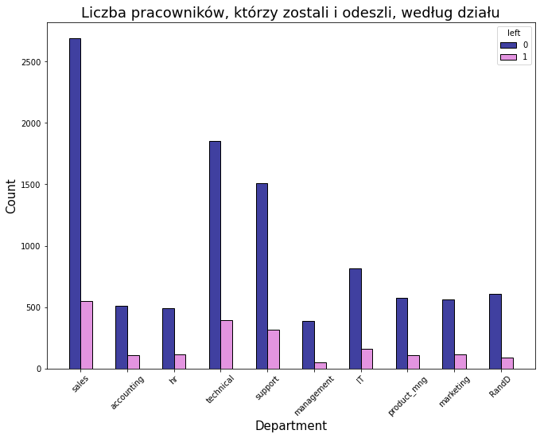

```python
# Create a plot as needed
### YOUR CODE HERE ###
# Create stacked histogram to compare department distribution of employees who left to that of employees who didn't

plt.figure(figsize=(11,8))
custom_palette = ['navy', 'orchid']

sns.histplot(data=df1, x='department', hue='left', discrete=1, hue_order=[0, 1], multiple='dodge', shrink=.5,palette = custom_palette)
plt.xticks(rotation='45')
plt.title('Liczba pracowników, którzy zostali i odeszli, według działu', fontsize=18)
plt.xlabel('Department',fontsize=15)
plt.ylabel('Count',fontsize=15)
plt.show()
```

Żadna z jednostek nie wydaje się znacząco różnić pod względem odsetka pracowników, którzy odeszli, w porównaniu do tych, którzy pozostali.

Na koniec warto sprawdzić, czy w danych występują silne korelacje między poszczególnymi zmiennymi.

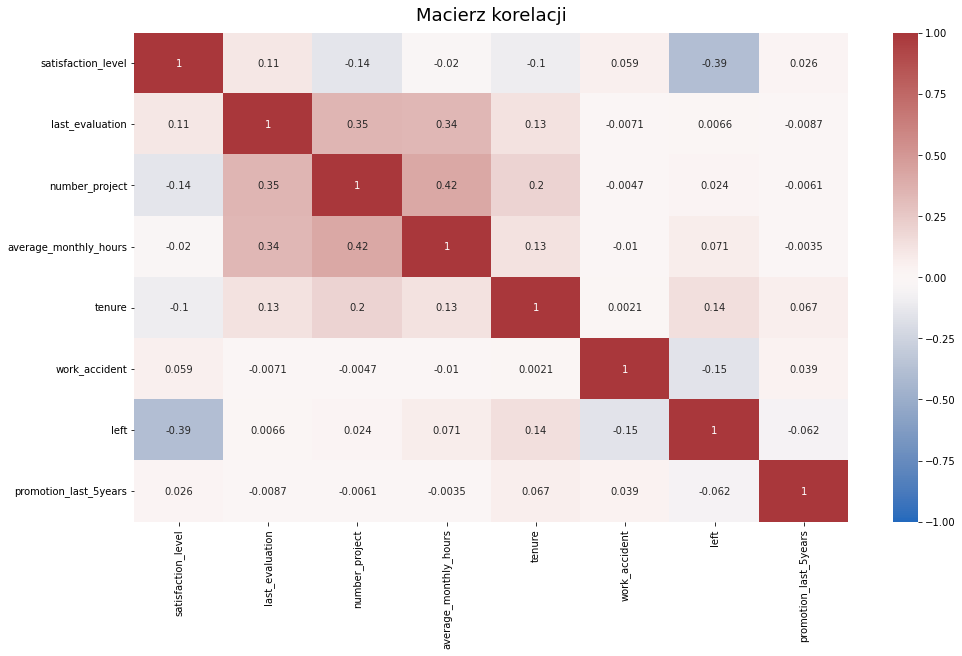

```python
# Create a plot as needed
### YOUR CODE HERE ###
# Plot a correlation heatmap

plt.figure(figsize=(16, 9))
heatmap = sns.heatmap(df0.corr(), vmin=-1, vmax=1, annot=True, cmap=sns.color_palette("vlag", as_cmap=True))
heatmap.set_title('Macierz korelacji', fontdict={'fontsize':18}, pad=12);
```

Macierz korelacji wskazuje, że `number_project`, `average_monthly` oraz `last_evaluation` są ze sobą dodatnio skorelowane, natomiast `left` jest ujemnie skorelowana z poziomem `satisfaction_level`.

### Wnioski

Z analizy sytuacji wynika, że pracownicy opuszczają firmę z powodu niewłaściwego zarządzania. Odejścia są związane z długimi godzinami pracy, dużą liczbą projektów oraz ogólnym spadkiem satysfakcji. Długotrwała praca bez awansów i pozytywnych ocen może być demotywująca. W firmie jest znacząca grupa pracowników, którzy mogą być wypaleni zawodowo. Dodatkowo, osoby, które spędziły w firmie więcej niż sześć lat, rzadziej decydują się na odejście.

## Tworzenie modelu, analiza wyników i ocena

Nszym celem jest przewidzenie, czy pracownik zdecyduje się opuścić firmę, co jest zmienną kategoryczną. W związku z tym zadanie polega na klasyfikacji. Konkretnie, jest to klasyfikacja binarna, ponieważ zmienna wynikowa `left` może przyjmować tylko dwie wartości: 1 (oznaczającą, że pracownik odszedł) lub 0 (oznaczającą, że pracownik pozostał).

### Identyfikacja modelu

Ponieważ zmienna, którą chcemy przewidzieć (czy pracownik, który opuszcza firmę), jest zmienną kategoryczną, możemy zastosować model regresji logistycznej lub model oparty na drzewach decyzyjnych

### Modelowanie

```python
### YOUR CODE HERE ###
df1.head()
```

|  | satisfaction_level | last_evaluation | number_project | average_monthly_hours | tenure | work_accident | left | promotion_last_5years | department | salary |
| --- | --- | --- | --- | --- | --- | --- | --- | --- | --- | --- |
| 0 | 0.38 | 0.53 | 2 | 157 | 3 | 0 | 1 | 0 | sales | low |
| 1 | 0.80 | 0.86 | 5 | 262 | 6 | 0 | 1 | 0 | sales | medium |
| 2 | 0.11 | 0.88 | 7 | 272 | 4 | 0 | 1 | 0 | sales | medium |
| 3 | 0.72 | 0.87 | 5 | 223 | 5 | 0 | 1 | 0 | sales | low |
| 4 | 0.37 | 0.52 | 2 | 159 | 3 | 0 | 1 | 0 | sales | low |

### Model regresji logistycznej

Przed przystąpieniem do podziału danych, należy odpowiednio zakodować zmienne nienumeryczne. W analizowanym zestawie danych znajdują się dwie takie zmienne: `department` oraz `salary`.

`Department`: Jest to zmienna kategoryczna, dlatego dla celów modelowania zaleca się zastosowanie kodowania za pomocą **dummy variables**.

`Salary`: Jest to zmienna kategoryczna o charakterze porządkowym, która posiada hierarchię kategorii. Z tego względu, zamiast kodowania przy użyciu dummy variables, bardziej odpowiednie będzie przekształcenie poziomów na wartości liczbowe w skali od 0 do 2.

```python
#copy the dataframe
df_new = df1.copy()

# Encode the `salary` column as an ordinal numeric category
df_new['salary'] = (df_new['salary'].astype('category').cat.set_categories(['low', 'medium', 'high']).cat.codes)

# Dummy encode the `department` column
df_new = pd.get_dummies(df_new, drop_first=False)

# Display the new dataframe
df_new.head()
```

|  | satisfaction_level | last_evaluation | number_project | average_monthly_hours | tenure | work_accident | left | promotion_last_5years | salary | department_IT | department_RandD | department_accounting | department_hr | department_management | department_marketing | department_product_mng | department_sales | department_support | department_technical |
| --- | --- | --- | --- | --- | --- | --- | --- | --- | --- | --- | --- | --- | --- | --- | --- | --- | --- | --- | --- |
| 0 | 0.38 | 0.53 | 2 | 157 | 3 | 0 | 1 | 0 | 0 | 0 | 0 | 0 | 0 | 0 | 0 | 0 | 1 | 0 | 0 |
| 1 | 0.80 | 0.86 | 5 | 262 | 6 | 0 | 1 | 0 | 1 | 0 | 0 | 0 | 0 | 0 | 0 | 0 | 1 | 0 | 0 |
| 2 | 0.11 | 0.88 | 7 | 272 | 4 | 0 | 1 | 0 | 1 | 0 | 0 | 0 | 0 | 0 | 0 | 0 | 1 | 0 | 0 |
| 3 | 0.72 | 0.87 | 5 | 223 | 5 | 0 | 1 | 0 | 0 | 0 | 0 | 0 | 0 | 0 | 0 | 0 | 1 | 0 | 0 |
| 4 | 0.37 | 0.52 | 2 | 159 | 3 | 0 | 1 | 0 | 0 | 0 | 0 | 0 | 0 | 0 | 0 | 0 | 1 | 0 | 0 |

Aby lepiej zrozumieć związki między zmiennymi w naszym zestawie danych, opracujemy macierz korelacji.

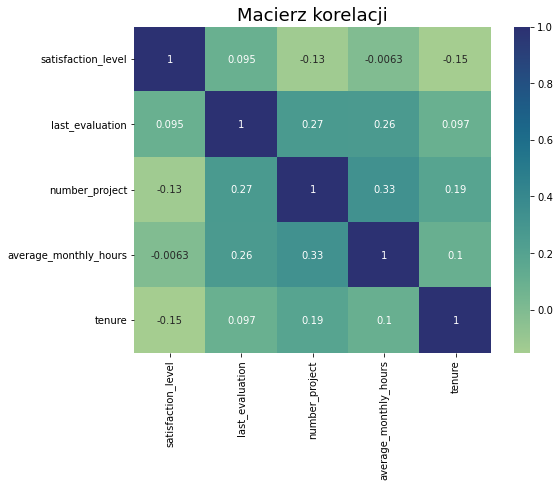

```python
# Create a heatmap to visualize how correlated variables are
plt.figure(figsize=(8, 6))
sns.heatmap(df_new[['satisfaction_level', 'last_evaluation', 'number_project', 'average_monthly_hours', 'tenure']]
            .corr(), annot=True, cmap="crest")
plt.title('Macierz korelacji',fontsize=18)
plt.show()
```

Stwórzmy wykres słupkowy, który pokaże liczbę pracowników w różnych działach, porównując osoby, które opuściły firmę, z tymi, które pozostały.

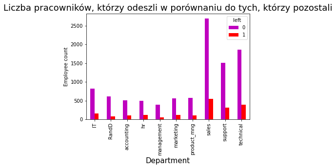

```python
# In the legend, 0 (purple color) represents employees who did not leave, 1 (red color) represents employees who left
plt.figure(figsize=(35, 25))
pd.crosstab(df1['department'], df1['left']).plot(kind ='bar',color='mr')
plt.title('Liczba pracowników, którzy odeszli w porównaniu do tych, którzy pozostali',fontsize=18)
plt.ylabel('Employee count')
plt.xlabel('Department',fontsize=15)
plt.show()
```

Ponieważ regresja logistyczna jest szczególnie wrażliwa na wartości odstające, na tym etapie zaleca się usunięcie wartości odstających w kolumnie `tenure`, które zostały wcześniej zidentyfikowane.

```python
# Select rows without outliers in `tenure` and save resulting dataframe in a new variable
df_logreg = df_new[(df_new['tenure'] >= lower_limit) & (df_new['tenure'] <= upper_limit)]

# Display first few rows of new dataframe
df_logreg.head()
```

|  | satisfaction_level | last_evaluation | number_project | average_monthly_hours | tenure | work_accident | left | promotion_last_5years | salary | department_IT | department_RandD | department_accounting | department_hr | department_management | department_marketing | department_product_mng | department_sales | department_support | department_technical |
| --- | --- | --- | --- | --- | --- | --- | --- | --- | --- | --- | --- | --- | --- | --- | --- | --- | --- | --- | --- |
| 0 | 0.38 | 0.53 | 2 | 157 | 3 | 0 | 1 | 0 | 0 | 0 | 0 | 0 | 0 | 0 | 0 | 0 | 1 | 0 | 0 |
| 2 | 0.11 | 0.88 | 7 | 272 | 4 | 0 | 1 | 0 | 1 | 0 | 0 | 0 | 0 | 0 | 0 | 0 | 1 | 0 | 0 |
| 3 | 0.72 | 0.87 | 5 | 223 | 5 | 0 | 1 | 0 | 0 | 0 | 0 | 0 | 0 | 0 | 0 | 0 | 1 | 0 | 0 |
| 4 | 0.37 | 0.52 | 2 | 159 | 3 | 0 | 1 | 0 | 0 | 0 | 0 | 0 | 0 | 0 | 0 | 0 | 1 | 0 | 0 |
| 5 | 0.41 | 0.50 | 2 | 153 | 3 | 0 | 1 | 0 | 0 | 0 | 0 | 0 | 0 | 0 | 0 | 0 | 1 | 0 | 0 |

W ramach przygotowania danych do modelowania, należy wydzielić zmienną docelową, którą model będzie przewidywał.

```python
# Isolate the outcome variable
y = df_logreg['left']

# Display first few rows of the outcome variable
y.head()
```

```
0    1
2    1
3    1
4    1
5    1
Name: left, dtype: int64
```

Wybierzmy cechy, które będą uwzględnione w modelu, i dokonajmy oceny, które zmienne najbardziej przyczynią się do przewidywania zmiennej `left`.

```python
# Select the features you want to use in your model
X = df_logreg.drop('left', axis=1)

# Display the first few rows of the selected features
X.head()
```

|  | satisfaction_level | last_evaluation | number_project | average_monthly_hours | tenure | work_accident | promotion_last_5years | salary | department_IT | department_RandD | department_accounting | department_hr | department_management | department_marketing | department_product_mng | department_sales | department_support | department_technical |
| --- | --- | --- | --- | --- | --- | --- | --- | --- | --- | --- | --- | --- | --- | --- | --- | --- | --- | --- |
| 0 | 0.38 | 0.53 | 2 | 157 | 3 | 0 | 0 | 0 | 0 | 0 | 0 | 0 | 0 | 0 | 0 | 1 | 0 | 0 |
| 2 | 0.11 | 0.88 | 7 | 272 | 4 | 0 | 0 | 1 | 0 | 0 | 0 | 0 | 0 | 0 | 0 | 1 | 0 | 0 |
| 3 | 0.72 | 0.87 | 5 | 223 | 5 | 0 | 0 | 0 | 0 | 0 | 0 | 0 | 0 | 0 | 0 | 1 | 0 | 0 |
| 4 | 0.37 | 0.52 | 2 | 159 | 3 | 0 | 0 | 0 | 0 | 0 | 0 | 0 | 0 | 0 | 0 | 1 | 0 | 0 |
| 5 | 0.41 | 0.50 | 2 | 153 | 3 | 0 | 0 | 0 | 0 | 0 | 0 | 0 | 0 | 0 | 0 | 1 | 0 | 0 |

Podzielmy dane na zestaw treningowy i testowy, pamiętając o stratyfikacji na podstawie wartości zmiennej `y`, ze względu na niezrównoważone klasy.

```python
# Split the data into training set and testing set
X_train, X_test, y_train, y_test = train_test_split(X, y, test_size=0.25, stratify=y, random_state=42)
```

Zbudujmy model regresji logistycznej i dopasujmy go do zestawu danych treningowych.

```python
# Construct a logistic regression model and fit it to the training dataset
log_clf = LogisticRegression(random_state=42, max_iter=500).fit(X_train, y_train)
```

Przetestujmy model regresji logistycznej, stosując go do prognozowania na zestawie testowym.

```python
# Use the logistic regression model to get predictions on the test set
y_pred = log_clf.predict(X_test)
```

Opracujmy macierz konfuzji, aby zobrazować wyniki modelu regresji logistycznej.

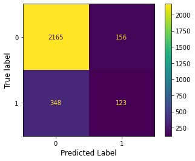

```python
# Compute values for confusion matrix
log_cm = confusion_matrix(y_test, y_pred, labels=log_clf.classes_)

# Create display of confusion matrix
log_disp = ConfusionMatrixDisplay(confusion_matrix=log_cm,
                                  display_labels=log_clf.classes_)

# Plot confusion matrix
log_disp.plot(values_format='')

plt.xlabel('Predicted Label', fontsize=12)
plt.ylabel('True label', fontsize=12)


# Display plot
plt.show()
```

Idealny model generowałby wyłącznie prawdziwe negatywy i prawdziwe pozytywy, eliminując jakiekolwiek fałszywe wyniki, zarówno pozytywne, jak i negatywne. Taki model osiągnąłby najwyższy poziom dokładności w przewidywaniu odejść pracowników, minimalizując liczbę błędnych klasyfikacji.

Sporządźmy raport klasyfikacyjny zawierający miary takie jak `accuracy`, `precision`, `recall` oraz `f1`, aby ocenić skuteczność modelu regresji logistycznej.

Zweryfikujmy równowagę klas w danych, analizując częstotliwość występowania wartości w kolumnie `left`. W przypadku klasyfikacji binarnej, rozkład klas ma znaczący wpływ na interpretację metryk dokładności.

```python
df_logreg['left'].value_counts(normalize=True)
```

```
0    0.831468
1    0.168532
Name: left, dtype: float64
```

Rozkład klas w naszym zestawie danych wynosi około 83% dla jednej klasy i 17% dla drugiej. Chociaż dane nie są doskonale zrównoważone, nierównomierność nie jest na poziomie skrajnie nierównym. W przypadku, gdyby wystąpiła bardziej znacząca nierównowaga klas, należałoby rozważyć zastosowanie technik **resamplingu**, takich jak **oversampling** lub **undersampling**, w celu uzyskania lepszej równowagi między klasami.

```python
# Create classification report for logistic regression model
target_names = ['Predicted would not leave', 'Predicted would leave']
print(classification_report(y_test, y_pred, target_names=target_names))
```

```
                           precision    recall  f1-score   support

Predicted would not leave       0.86      0.93      0.90      2321
    Predicted would leave       0.44      0.26      0.33       471

                 accuracy                           0.82      2792
                macro avg       0.65      0.60      0.61      2792
             weighted avg       0.79      0.82      0.80      2792
```

Raport klasyfikacji wskazuje, że model regresji logistycznej osiągnął `precision` na poziomie 79%, `recall` 82%, `f1` 80% (wszystkie jako średnie ważone) oraz `accuracy` 82%. Jednak jeśli priorytetem jest przewidywanie odejść pracowników, wyniki modelu są znacznie mniej satysfakcjonujące.

### Model oparty na drzewach decyzyjnych

Oddzielmy zmienną wynikową od pozostałych zmiennych.

```python
# Isolate the outcome variable
y = df_new['left']

# Display the first few rows of `y`
y.head()
```

```
0    1
1    1
2    1
3    1
4    1
Name: left, dtype: int64
```

Wybierzmy zmienne niezależne.

```python
# Select the features
X = df_new.drop('left', axis=1)

# Display the first few rows of `X`
X.head()
```

|  | satisfaction_level | last_evaluation | number_project | average_monthly_hours | tenure | work_accident | promotion_last_5years | salary | department_IT | department_RandD | department_accounting | department_hr | department_management | department_marketing | department_product_mng | department_sales | department_support | department_technical |
| --- | --- | --- | --- | --- | --- | --- | --- | --- | --- | --- | --- | --- | --- | --- | --- | --- | --- | --- |
| 0 | 0.38 | 0.53 | 2 | 157 | 3 | 0 | 0 | 0 | 0 | 0 | 0 | 0 | 0 | 0 | 0 | 1 | 0 | 0 |
| 1 | 0.80 | 0.86 | 5 | 262 | 6 | 0 | 0 | 1 | 0 | 0 | 0 | 0 | 0 | 0 | 0 | 1 | 0 | 0 |
| 2 | 0.11 | 0.88 | 7 | 272 | 4 | 0 | 0 | 1 | 0 | 0 | 0 | 0 | 0 | 0 | 0 | 1 | 0 | 0 |
| 3 | 0.72 | 0.87 | 5 | 223 | 5 | 0 | 0 | 0 | 0 | 0 | 0 | 0 | 0 | 0 | 0 | 1 | 0 | 0 |
| 4 | 0.37 | 0.52 | 2 | 159 | 3 | 0 | 0 | 0 | 0 | 0 | 0 | 0 | 0 | 0 | 0 | 1 | 0 | 0 |

```python
# Split the data
X_train, X_test, y_train, y_test = train_test_split(X, y, test_size=0.25, stratify=y, random_state=0)
```

#### Drzewo decyzyjne

Stwórzmy model drzewa decyzyjnego.

```python
# Instantiate model
tree = DecisionTreeClassifier(random_state=0)

# Assign a dictionary of hyperparameters to search over
cv_params = {'max_depth':[4, 6, 8, None],
             'min_samples_leaf': [2, 5, 1],
             'min_samples_split': [2, 4, 6]
             }

# Assign a dictionary of scoring metrics to capture
scoring = {'accuracy', 'precision', 'recall', 'f1', 'roc_auc'}

# Instantiate GridSearch
tree1 = GridSearchCV(tree, cv_params, scoring=scoring, cv=4, refit='roc_auc')
```

Dopasujmy model drzewa decyzyjnego do danych treningowych.

```python
%%time
tree1.fit(X_train, y_train)
```

```
CPU times: user 2.94 s, sys: 0 ns, total: 2.94 s
Wall time: 2.94 s
```

```
GridSearchCV(cv=4, error_score=nan,
             estimator=DecisionTreeClassifier(ccp_alpha=0.0, class_weight=None,
                                              criterion='gini', max_depth=None,
                                              max_features=None,
                                              max_leaf_nodes=None,
                                              min_impurity_decrease=0.0,
                                              min_impurity_split=None,
                                              min_samples_leaf=1,
                                              min_samples_split=2,
                                              min_weight_fraction_leaf=0.0,
                                              presort='deprecated',
                                              random_state=0, splitter='best'),
             iid='deprecated', n_jobs=None,
             param_grid={'max_depth': [4, 6, 8, None],
                         'min_samples_leaf': [2, 5, 1],
                         'min_samples_split': [2, 4, 6]},
             pre_dispatch='2*n_jobs', refit='roc_auc', return_train_score=False,
             scoring={'f1', 'precision', 'accuracy', 'recall', 'roc_auc'},
             verbose=0)
```

Określmy optymalne wartości parametrów dla drzewa decyzyjnego.

```python
# Check best parameters
tree1.best_params_
```

```
{'max_depth': 4, 'min_samples_leaf': 5, 'min_samples_split': 2}
```

Aby ocenić efektywność modelu drzewa decyzyjnego, określimy najwyższy uzyskany wynik `AUC` (Area Under the Curve) na zbiorze treningowym

```python
# Check best AUC score on CV
tree1.best_score_
```

```
0.969819392792457
```

Wysoki wynik `AUC` wskazuje, że model skutecznie przewiduje, którzy pracownicy odejdą z firmy. Aby kontynuować analizę i w pełni wykorzystać potencjał modelu, następnym krokiem będzie stworzenie funkcji, która umożliwi wyodrębnienie wszystkich wyników prognozowanych przez model.

```python
def make_results(model_name:str, model_object, metric:str):
    '''
    Arguments:
        model_name (string): what you want the model to be called in the output table
        model_object: a fit GridSearchCV object
        metric (string): precision, recall, f1, accuracy, or auc

    Returns a pandas df with the F1, recall, precision, accuracy, and auc scores
    for the model with the best mean 'metric' score across all validation folds.
    '''

    # Create dictionary that maps input metric to actual metric name in GridSearchCV
    metric_dict = {'auc': 'mean_test_roc_auc',
                   'precision': 'mean_test_precision',
                   'recall': 'mean_test_recall',
                   'f1': 'mean_test_f1',
                   'accuracy': 'mean_test_accuracy'
                  }

    # Get all the results from the CV and put them in a df
    cv_results = pd.DataFrame(model_object.cv_results_)

    # Isolate the row of the df with the max(metric) score
    best_estimator_results = cv_results.iloc[cv_results[metric_dict[metric]].idxmax(), :]

    # Extract Accuracy, precision, recall, and f1 score from that row
    auc = best_estimator_results.mean_test_roc_auc
    f1 = best_estimator_results.mean_test_f1
    recall = best_estimator_results.mean_test_recall
    precision = best_estimator_results.mean_test_precision
    accuracy = best_estimator_results.mean_test_accuracy

    # Create table of results
    table = pd.DataFrame()
    table = pd.DataFrame({'model': [model_name],
                          'precision': [precision],
                          'recall': [recall],
                          'F1': [f1],
                          'accuracy': [accuracy],
                          'auc': [auc]
                        })

    return table
```

Aby uzyskać wszystkie wyniki prognozowane przez model drzewa decyzyjnego, skorzystajmy z wcześniej zdefiniowanej funkcji.

```python
# Get all CV scores
tree1_cv_results = make_results('decision tree cv', tree1, 'auc')
tree1_cv_results
```

|  | model | precision | recall | F1 | accuracy | auc |
| --- | --- | --- | --- | --- | --- | --- |
| 0 | decision tree cv | 0.914552 | 0.916949 | 0.915707 | 0.971978 | 0.969819 |

Wszystkie wyniki uzyskane z modelu drzewa decyzyjnego wskazują na wysoką jakość jego działania.

Należy pamiętać, że drzewa decyzyjne mogą być narażone na przeuczenie, natomiast lasy losowe przeciwdziałają temu problemowi, wykorzystując wiele drzew do tworzenia prognoz. Następnym krokiem w procesie analizy danych i modelowania może być skonstruowanie modelu lasu losowego

#### Las losowy

Zbudujmy model lasu losowego i skonfiguruj proces krzyżowej walidacji, aby precyzyjnie określić optymalne parametry modelu.

```python
# Instantiate model
rf = RandomForestClassifier(random_state=0)

# Assign a dictionary of hyperparameters to search over
cv_params = {'max_depth': [3,5, None],
             'max_features': [1.0],
             'max_samples': [0.7, 1.0],
             'min_samples_leaf': [1,2,3],
             'min_samples_split': [2,3,4],
             'n_estimators': [300, 500],
             }

# Assign a dictionary of scoring metrics to capture
scoring = {'accuracy', 'precision', 'recall', 'f1', 'roc_auc'}

# Instantiate GridSearch
rf1 = GridSearchCV(rf, cv_params, scoring=scoring, cv=4, refit='roc_auc')
```

Dopasujmy model lasu losowego do danych treningowych.

```python
%%time
model = rf1.fit(X_train, y_train) # --> Wall time: ~10min
```

```
CPU times: user 9min 30s, sys: 0 ns, total: 9min 30s
Wall time: 9min 30s
```

```python
model
```

```
GridSearchCV(cv=4, error_score=nan,
             estimator=RandomForestClassifier(bootstrap=True, ccp_alpha=0.0,
                                              class_weight=None,
                                              criterion='gini', max_depth=None,
                                              max_features='auto',
                                              max_leaf_nodes=None,
                                              max_samples=None,
                                              min_impurity_decrease=0.0,
                                              min_impurity_split=None,
                                              min_samples_leaf=1,
                                              min_samples_split=2,
                                              min_weight_fraction_leaf=0.0,
                                              n_estimators=100, n_jobs=None,...
                                              verbose=0, warm_start=False),
             iid='deprecated', n_jobs=None,
             param_grid={'max_depth': [3, 5, None], 'max_features': [1.0],
                         'max_samples': [0.7, 1.0],
                         'min_samples_leaf': [1, 2, 3],
                         'min_samples_split': [2, 3, 4],
                         'n_estimators': [300, 500]},
             pre_dispatch='2*n_jobs', refit='roc_auc', return_train_score=False,
             scoring={'f1', 'precision', 'accuracy', 'recall', 'roc_auc'},
             verbose=0)
```

Określmy najwyższy uzyskany wynik `AUC` dla modelu lasu losowego na zbiorze treningowym.

```python
# Check best AUC score on CV
model.best_score_
```

```
0.9804250949807172
```

Określmy optymalne wartości parametrów dla modelu lasu losowego.

```python
# Check best params
model.best_params_
```

```
{'max_depth': 5,
 'max_features': 1.0,
 'max_samples': 0.7,
 'min_samples_leaf': 1,
 'min_samples_split': 4,
 'n_estimators': 500}
```

Zbierzmy wyniki ewaluacji dla modelu drzewa decyzyjnego oraz modelu lasu losowego na zbiorze treningowym.

```python
# Get all CV scores
rf1_cv_results = make_results('random forest cv', model, 'auc')
print(tree1_cv_results)
print(rf1_cv_results)
```

```
              model  precision    recall        F1  accuracy       auc
0  decision tree cv   0.914552  0.916949  0.915707  0.971978  0.969819
              model  precision    recall        F1  accuracy       auc
0  random forest cv   0.950023  0.915614  0.932467  0.977983  0.980425
```

Wyniki oceny modelu lasu losowego przewyższają wyniki modelu drzewa decyzyjnego, z wyjątkiem `recall`, gdzie wynik lasu losowego jest około 0.001 niższy, co stanowi minimalną różnicę. Ogólnie rzecz biorąc, model lasu losowego wykazuje lepszą wydajność niż model drzewa decyzyjnego.

Kolejnym krokiem jest przeprowadzenie oceny ostatecznego modelu na zbiorze testowym.

Zdefiniujmy funkcję, która umożliwia pozyskanie wszystkich wyników prognoz generowanych przez model.

```python
def get_scores(model_name:str, model, X_test_data, y_test_data):
    '''
    Generate a table of test scores.

    In:
        model_name (string):  How you want your model to be named in the output table
        model:                A fit GridSearchCV object
        X_test_data:          numpy array of X_test data
        y_test_data:          numpy array of y_test data

    Out: pandas df of precision, recall, f1, accuracy, and AUC scores for your model
    '''

    preds = model.best_estimator_.predict(X_test_data)

    auc = roc_auc_score(y_test_data, preds)
    accuracy = accuracy_score(y_test_data, preds)
    precision = precision_score(y_test_data, preds)
    recall = recall_score(y_test_data, preds)
    f1 = f1_score(y_test_data, preds)

    table = pd.DataFrame({'model': [model_name],
                          'precision': [precision],
                          'recall': [recall],
                          'f1': [f1],
                          'accuracy': [accuracy],
                          'AUC': [auc]
                         })

    return table
```

```python
# Get predictions on test data
rf1_test_scores = get_scores('random forest1 test', rf1, X_test, y_test)
rf1_test_scores
```

|  | model | precision | recall | f1 | accuracy | AUC |
| --- | --- | --- | --- | --- | --- | --- |
| 0 | random forest1 test | 0.964211 | 0.919679 | 0.941418 | 0.980987 | 0.956439 |

Wyniki testów są niemal identyczne z wynikami walidacji, co stanowi pozytywny sygnał i sugeruje, że model jest solidny. Ponieważ ten zbiór testowy został wykorzystany wyłącznie dla tego modelu, istnieje większa pewność, że uzyskane wyniki odzwierciedlają rzeczywistą skuteczność modelu w przypadku nowych, nieznanych danych.

Wysokie wyniki oceny mogą budzić wątpliwości z uwagi na ryzyko wycieku danych. Istnieje możliwość, że model był trenowany na informacjach, które nie powinny być dostępne podczas procesu trenowania, ponieważ mogą wystąpić w danych testowych lub nie będą dostępne po wdrożeniu modelu. Trenowanie na takich danych może prowadzić do nierealistycznych wyników, które nie odzwierciedlają rzeczywistej wydajności modelu w praktyce.

W tym przypadku istnieje ryzyko, że firma nie dysponuje pełnymi raportami na temat poziomu satysfakcji wszystkich pracowników. Może również wystąpić sytuacja, w której kolumna `average_monthly_hours` jest źródłem wycieku danych. Pracownicy, którzy zdecydowali się odejść lub zostali wskazani do zwolnienia, mogą pracować mniej godzin, co może wpływać na wyniki modelu.

W pierwszej rundzie modeli drzewa decyzyjnego i lasu losowego uwzględniono wszystkie zmienne jako cechy. W kolejnej rundzie skoncentrujemy się na inżynierii cech, aby poprawić modele.

Kolejnym krokiem będzie usunięcie zmiennej `satisfaction_level` oraz wprowadzenie nowej cechy, która będzie przybliżać stan przepracowania pracowników. Nową cechę nazwiemy `overworked`, a będzie to zmienna binarna.

```python
# Drop `satisfaction_level` and save resulting dataframe in new variable
df2 = df_new.drop('satisfaction_level', axis=1)

# Display first few rows of new dataframe
df2.head()
```

|  | last_evaluation | number_project | average_monthly_hours | tenure | work_accident | left | promotion_last_5years | salary | department_IT | department_RandD | department_accounting | department_hr | department_management | department_marketing | department_product_mng | department_sales | department_support | department_technical |
| --- | --- | --- | --- | --- | --- | --- | --- | --- | --- | --- | --- | --- | --- | --- | --- | --- | --- | --- |
| 0 | 0.53 | 2 | 157 | 3 | 0 | 1 | 0 | 0 | 0 | 0 | 0 | 0 | 0 | 0 | 0 | 1 | 0 | 0 |
| 1 | 0.86 | 5 | 262 | 6 | 0 | 1 | 0 | 1 | 0 | 0 | 0 | 0 | 0 | 0 | 0 | 1 | 0 | 0 |
| 2 | 0.88 | 7 | 272 | 4 | 0 | 1 | 0 | 1 | 0 | 0 | 0 | 0 | 0 | 0 | 0 | 1 | 0 | 0 |
| 3 | 0.87 | 5 | 223 | 5 | 0 | 1 | 0 | 0 | 0 | 0 | 0 | 0 | 0 | 0 | 0 | 1 | 0 | 0 |
| 4 | 0.52 | 2 | 159 | 3 | 0 | 1 | 0 | 0 | 0 | 0 | 0 | 0 | 0 | 0 | 0 | 1 | 0 | 0 |

```python
# Create `overworked` column. For now, it's identical to average monthly hours.
df2['overworked'] = df2['average_monthly_hours']

# Inspect max and min average monthly hours values
print('Max hours:', df2['overworked'].max())
print('Min hours:', df2['overworked'].min())
```

```
Max hours: 310
Min hours: 96
```

166,67 godzin to w przybliżeniu średnia liczba godzin pracy miesięcznie dla osoby pracującej 50 tygodni w roku, 5 dni w tygodniu, po 8 godzin dziennie.

Możemy zdefiniować, że pracownik jest przepracowany, jeśli jego średnia liczba godzin pracy miesięcznie przekracza 175 godzin.

Stwórzmy binarną kolumnę `overworked`, gdzie

- `df3['overworked'] > 175` tworzy serię wartości logicznych, gdzie `True` oznacza wartości większe niż 175, a `False` oznacza wartości mniejsze lub równe 175.
- `.astype(int)` przekształca wszystkie wartości `True` na `1`, a wszystkie wartości `False` na `0`

```python
# Define `overworked` as working > 175 hrs/week
df2['overworked'] = (df2['overworked'] > 175).astype(int)

# Display first few rows of new column
df2['overworked'].head()
```

```
0    0
1    1
2    1
3    1
4    0
Name: overworked, dtype: int64
```

Usuńmy kolumnę `average_monthly_hours`.

```python
# Drop the `average_monthly_hours` column
df2 = df2.drop('average_monthly_hours', axis=1)

# Display first few rows of resulting dataframe
df2.head()
```

|  | last_evaluation | number_project | tenure | work_accident | left | promotion_last_5years | salary | department_IT | department_RandD | department_accounting | department_hr | department_management | department_marketing | department_product_mng | department_sales | department_support | department_technical | overworked |
| --- | --- | --- | --- | --- | --- | --- | --- | --- | --- | --- | --- | --- | --- | --- | --- | --- | --- | --- |
| 0 | 0.53 | 2 | 3 | 0 | 1 | 0 | 0 | 0 | 0 | 0 | 0 | 0 | 0 | 0 | 1 | 0 | 0 | 0 |
| 1 | 0.86 | 5 | 6 | 0 | 1 | 0 | 1 | 0 | 0 | 0 | 0 | 0 | 0 | 0 | 1 | 0 | 0 | 1 |
| 2 | 0.88 | 7 | 4 | 0 | 1 | 0 | 1 | 0 | 0 | 0 | 0 | 0 | 0 | 0 | 1 | 0 | 0 | 1 |
| 3 | 0.87 | 5 | 5 | 0 | 1 | 0 | 0 | 0 | 0 | 0 | 0 | 0 | 0 | 0 | 1 | 0 | 0 | 1 |
| 4 | 0.52 | 2 | 3 | 0 | 1 | 0 | 0 | 0 | 0 | 0 | 0 | 0 | 0 | 0 | 1 | 0 | 0 | 0 |

Ponownie wyodrębnijmy zmienne predykcyjne oraz zmienną docelową.

```python
# Isolate the outcome variable
y = df2['left']

# Select the features
X = df2.drop('left', axis=1)
```

Podzielmy dane na zbiory treningowe i testowe.

```python
# Create test data
X_train, X_test, y_train, y_test = train_test_split(X, y, test_size=0.25, stratify=y, random_state=0)
```

#### Drzewo decyzyjne

```python
# Instantiate model
tree = DecisionTreeClassifier(random_state=0)

# Assign a dictionary of hyperparameters to search over
cv_params = {'max_depth':[4, 6, 8, None],
             'min_samples_leaf': [2, 5, 1],
             'min_samples_split': [2, 4, 6]
             }

# Assign a dictionary of scoring metrics to capture
scoring = {'accuracy', 'precision', 'recall', 'f1', 'roc_auc'}

# Instantiate GridSearch
tree2 = GridSearchCV(tree, cv_params, scoring=scoring, cv=4, refit='roc_auc')
```

```python
%%time
tree2.fit(X_train, y_train)
```

```
CPU times: user 2.3 s, sys: 0 ns, total: 2.3 s
Wall time: 2.3 s
```

```
GridSearchCV(cv=4, error_score=nan,
             estimator=DecisionTreeClassifier(ccp_alpha=0.0, class_weight=None,
                                              criterion='gini', max_depth=None,
                                              max_features=None,
                                              max_leaf_nodes=None,
                                              min_impurity_decrease=0.0,
                                              min_impurity_split=None,
                                              min_samples_leaf=1,
                                              min_samples_split=2,
                                              min_weight_fraction_leaf=0.0,
                                              presort='deprecated',
                                              random_state=0, splitter='best'),
             iid='deprecated', n_jobs=None,
             param_grid={'max_depth': [4, 6, 8, None],
                         'min_samples_leaf': [2, 5, 1],
                         'min_samples_split': [2, 4, 6]},
             pre_dispatch='2*n_jobs', refit='roc_auc', return_train_score=False,
             scoring={'f1', 'precision', 'accuracy', 'recall', 'roc_auc'},
             verbose=0)
```

```python
# Check best params
tree2.best_params_
```

```
{'max_depth': 6, 'min_samples_leaf': 2, 'min_samples_split': 6}
```

```python
# Check best AUC score on CV
tree2.best_score_
```

```
0.9586752505340426
```

Model ten osiąga bardzo dobre wyniki, nawet bez uwzględnienia poziomu satysfakcji i szczegółowych danych dotyczących przepracowanych godzin.

Następnie sprawdźmy pozostałe wskaźniki.

```python
# Get all CV scores
tree2_cv_results = make_results('decision tree2 cv', tree2, 'auc')
print(tree1_cv_results)
print(tree2_cv_results)
```

```
              model  precision    recall        F1  accuracy       auc
0  decision tree cv   0.914552  0.916949  0.915707  0.971978  0.969819
               model  precision    recall        F1  accuracy       auc
0  decision tree2 cv   0.856693  0.903553  0.878882  0.958523  0.958675
```

Niektóre z pozostałych wskaźników uległy pogorszeniu, co jest naturalne, biorąc pod uwagę mniejszą liczbę uwzględnionych cech modelu. Niemniej jednak, wyniki wciąż są bardzo dobre.

#### Las losowy

```python
# Instantiate model
rf = RandomForestClassifier(random_state=0)

# Assign a dictionary of hyperparameters to search over
cv_params = {'max_depth': [3,5, None],
             'max_features': [1.0],
             'max_samples': [0.7, 1.0],
             'min_samples_leaf': [1,2,3],
             'min_samples_split': [2,3,4],
             'n_estimators': [300, 500],
             }

# Assign a dictionary of scoring metrics to capture
scoring = {'accuracy', 'precision', 'recall', 'f1', 'roc_auc'}

# Instantiate GridSearch
rf2 = GridSearchCV(rf, cv_params, scoring=scoring, cv=4, refit='roc_auc')
```

```python
%%time
model2 = rf2.fit(X_train, y_train) # --> Wall time: 7min 5s
```

```
CPU times: user 6min 59s, sys: 0 ns, total: 6min 59s
Wall time: 6min 59s
```

```python
# Check best params
model2.best_params_
```

```
{'max_depth': 5,
 'max_features': 1.0,
 'max_samples': 0.7,
 'min_samples_leaf': 2,
 'min_samples_split': 2,
 'n_estimators': 300}
```

```python
# Check best AUC score on CV
model2.best_score_
```

```
0.9648100662833985
```

```python
# Get all CV scores
rf2_cv_results = make_results('random forest2 cv',model2, 'auc')
print(tree2_cv_results)
print(rf2_cv_results)
```

```
               model  precision    recall        F1  accuracy       auc
0  decision tree2 cv   0.856693  0.903553  0.878882  0.958523  0.958675
               model  precision    recall        F1  accuracy      auc
0  random forest2 cv   0.866758  0.878754  0.872407  0.957411  0.96481
```

Wyniki ponownie uległy nieznacznemu obniżeniu, jednak model lasu losowego nadal przewyższa model drzewa decyzyjnego, szczególnie w kontekście kluczowego wskaźnika, jakim jest `AUC`.

Kolejnym krokiem jest przetestowanie najlepszego modelu na zbiorze testowym.

```python
# Get predictions on test data
rf2_test_scores = get_scores('random forest2 test',model2, X_test, y_test)
rf2_test_scores
```

|  | model | precision | recall | f1 | accuracy | AUC |
| --- | --- | --- | --- | --- | --- | --- |
| 0 | random forest2 test | 0.870406 | 0.903614 | 0.8867 | 0.961641 | 0.938407 |

Wydaje się, że model końcowy jest stabilny i efektywny.

Stwórzmy macierz pomyłek, aby ocenić skuteczność modelu w przewidywaniu na zbiorze testowym.

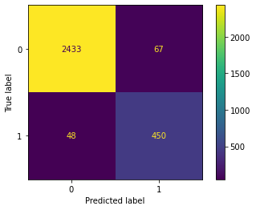

```python
# Generate array of values for confusion matrix
preds = model2.best_estimator_.predict(X_test)
cm = confusion_matrix(y_test, preds, labels=rf2.classes_)

# Plot confusion matrix
disp = ConfusionMatrixDisplay(confusion_matrix=cm,
                             display_labels=model2.classes_)
disp.plot(values_format='');
```

Model generuje więcej **fałszywych pozytywów** niż **fałszywych negatywów**, co sugeruje, że niektórzy pracownicy mogą być błędnie klasyfikowani jako zagrożeni odejściem lub zwolnieniem, mimo że w rzeczywistości taka sytuacja nie zachodzi. Niemniej jednak, model pozostaje uznawany za solidny.

W celach analitycznych warto szczegółowo przeanalizować podziały w modelu drzewa decyzyjnego oraz zidentyfikować kluczowe cechy w modelu lasu losowego.

#### Podział drzewa decyzyjnego

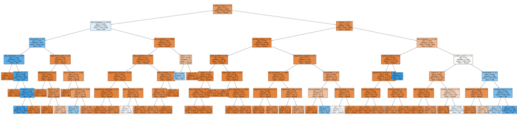

```python
# Plot the tree
plt.figure(figsize=(85,20))
plot_tree(tree2.best_estimator_, max_depth=6, fontsize=14, feature_names=X.columns,
          class_names={0:'stayed', 1:'left'}, filled=True);
plt.show()
```

#### Ważność cech w drzewach decyzyjnych

Ważność cech można również uzyskać z drzew decyzyjnych (zobacz dokumentację [DecisionTreeClassifier scikit-learn documentation](https://scikit-learn.org/stable/modules/generated/sklearn.tree.DecisionTreeClassifier.html#sklearn.tree.DecisionTreeClassifier.feature_importances_)).

```python
#tree2_importances = pd.DataFrame(tree2.best_estimator_.feature_importances_, columns=X.columns)
tree2_importances = pd.DataFrame(tree2.best_estimator_.feature_importances_,
                                 columns=['gini_importance'],
                                 index=X.columns
                                )
tree2_importances = tree2_importances.sort_values(by='gini_importance', ascending=False)

# Only extract the features with importances > 0
tree2_importances = tree2_importances[tree2_importances['gini_importance'] != 0]
tree2_importances
```

|  | gini_importance |
| --- | --- |
| last_evaluation | 0.343958 |
| number_project | 0.343385 |
| tenure | 0.215681 |
| overworked | 0.093498 |
| department_support | 0.001142 |
| salary | 0.000910 |
| department_sales | 0.000607 |
| department_technical | 0.000418 |
| work_accident | 0.000183 |
| department_IT | 0.000139 |
| department_marketing | 0.000078 |

Następnie przedstawmy wykres słupkowy, aby wizualizować ważność cech w drzewie decyzyjnym.

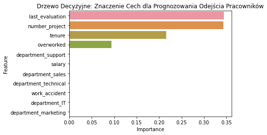

```python
sns.barplot(data=tree2_importances, x="gini_importance", y=tree2_importances.index, orient='h')
plt.title("Drzewo Decyzyjne: Znaczenie Cech dla Prognozowania Odejścia Pracowników", fontsize=12)
plt.ylabel("Feature")
plt.xlabel("Importance")
plt.show()
```

Powyższy wykres słupkowy pokazuje, że w modelu drzewa decyzyjnego cechy `last_evaluation`, `number_project`, `tenure` oraz `overworked` mają najwyższe znaczenie, w podanej kolejności. Te zmienne są kluczowe dla przewidywania zmiennej docelowej, czyli `left`.

#### Ważność cech w lesie losowym

Stwórzmy wykres ważności cech dla modelu lasu losowego.

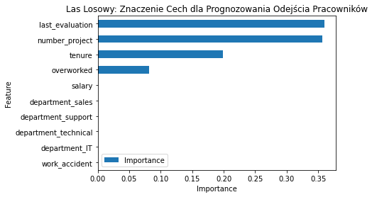

```python
# Get feature importances
feat_impt = model2.best_estimator_.feature_importances_

# Get indices of top 10 features
ind = np.argpartition(model2.best_estimator_.feature_importances_, -10)[-10:]

# Get column labels of top 10 features
feat = X.columns[ind]

# Filter `feat_impt` to consist of top 10 feature importances
feat_impt = feat_impt[ind]

y_df = pd.DataFrame({"Feature":feat,"Importance":feat_impt})
y_sort_df = y_df.sort_values("Importance")
fig = plt.figure()
ax1 = fig.add_subplot(111)

y_sort_df.plot(kind='barh',ax=ax1,x="Feature",y="Importance")

ax1.set_title("Las Losowy: Znaczenie Cech dla Prognozowania Odejścia Pracowników", fontsize=12)
ax1.set_ylabel("Feature")
ax1.set_xlabel("Importance")

plt.show()
```

Powyższy wykres ilustruje, że w modelu lasu losowego cechy `last_evaluation`, `number_project`,`tenure` oraz `overworked` mają najwyższą ważność, w tej właśnie kolejności. Te zmienne są kluczowe dla przewidywania zmiennej wynikowej `left` i są identyczne z tymi używanymi w modelu drzewa decyzyjnego.

### Metryki oceny skuteczności modelu

- **AUC** (Area Under the Curve) to pole pod krzywą ROC, które odzwierciedla prawdopodobieństwo, że model poprawnie oceni losowy pozytywny przykład wyżej niż losowy negatywny przykład.
- **Precyzja** mierzy proporcję punktów danych przewidzianych jako pozytywne, które są rzeczywiście pozytywne. Innymi słowy, jest to stosunek prawdziwych pozytywów do wszystkich prognoz pozytywnych.
- **Czułość** (Recall) ocenia proporcję punktów danych, które zostały przewidziane jako pozytywne, w odniesieniu do wszystkich rzeczywiście pozytywnych punktów danych. Wskazuje, jaki odsetek rzeczywistych pozytywów został poprawnie sklasyfikowany przez model.
- **Dokładność** (Accuracy) mierzy stosunek punktów danych, które zostały poprawnie sklasyfikowane, do całkowitej liczby punktów danych. Odzwierciedla ogólną skuteczność modelu.
- **Miara F1** to połączenie precyzji i czułości w jedną miarę, która uwzględnia zarówno fałszywe pozytywy, jak i fałszywe negatywy, zapewniając równowagę między tymi dwoma wskaźnikami.

## Podsumowanie wyników modelu

### Wnioski, Rekomendacje

Analiza modeli oraz ważność cech potwierdzają, że pracownicy w firmie są przeciążeni pracą.

Aby poprawić retencję pracowników, warto przedstawić interesariuszom następujące rekomendacje:

- `Ograniczenie liczby projektów`: Wprowadzić limit dotyczący liczby projektów, nad którymi mogą pracować pracownicy, aby uniknąć ich przeciążenia.
- `Promocje i badania`: Rozważyć awans dla pracowników, którzy są z firmą co najmniej cztery lata, lub przeprowadź dodatkowe badania, aby zrozumieć, dlaczego pracownicy z długim stażem są niezadowoleni.
- `Wynagrodzenie za nadgodziny`: Nagrodzić pracowników za długie godziny pracy lub rozważ zmniejszenie wymagań dotyczących pracy w nadgodzinach.
- `Polityka wynagrodzeń za nadgodziny`: Upewnić się, że pracownicy są dobrze poinformowani o polityce wynagrodzenia za nadgodziny. Jeśli oczekiwania dotyczące obciążenia pracą i urlopu nie są jasno określone, spraw, aby były one jednoznaczne.
- `Kultura pracy`: Zorganizować spotkania w firmie oraz w zespołach, aby lepiej zrozumieć i poprawić kulturę pracy w firmie oraz dostosować ją do potrzeb pracowników.
- `Sprawiedliwa ocena`: Unikać przyznawania wysokich ocen wyłącznie pracownikom, którzy pracują powyżej 200 godzin miesięcznie. Rozważ wprowadzenie proporcjonalnej skali nagradzania, która sprawiedliwie odzwierciedli wkład pracowników i ich wysiłek.